# SC Shellfish Mariculture Governance Network

Stakeholder Network Analysis | Kate Chatman | MPA/EVSS Thesis | College of Charleston 2026

## About This Dashboard

This dashboard presents the Stakeholder Network Analysis (SNA) for Kate Chatman’s MPA/EVSS thesis examining administrative burden and coalition dynamics in South Carolina shellfish mariculture permitting. The network was built from primary data collected through the SC Sea Grant Consortium, SCDNR, SCDES, and USACE permitting documentation (2021–2026).

**Network summary:** 103 nodes · 272 unique edges · directed graph · fully connected

**Theoretical framework:** Herd & Moynihan (2015) administrative burden · Sabatier & Weible (2007) Advocacy Coalition Framework · Gould & Fernandez (1989) Brokerage Roles

## Full Governance Network

Node size = betweenness centrality. Color = actor type. Border color = coalition affiliation. Squares = institutional nodes; circles = individuals. Faded/dashed = historical (departed) actors. Use the **Filter by actor type** dropdown or click any node to highlight its immediate neighbors. Hover for full attribute tooltip.

```r
nodes_full <- nodes_base %>% mutate(value = btw_scaled[id])

visNetwork(
  nodes = nodes_full,
  edges = edges_vis,
  width = "100%", height = "800px"
) %>%
  visOptions(
    highlightNearest = list(enabled = TRUE, degree = 1, hover = TRUE),
    selectedBy       = list(variable = "group", main = "Filter by actor type"),
    nodesIdSelection = list(enabled = TRUE, main = "Select node")
  ) %>%
  visLegend(
    addNodes = legend_nodes, addEdges = legend_edges,
    useGroups = FALSE, position = "right", width = 0.18
  ) %>%
  visPhysics(
    solver = "forceAtlas2Based",
    forceAtlas2Based = list(
      gravitationalConstant = -80, centralGravity = 0.01,
      springLength = 120, springConstant = 0.08, damping = 0.4
    ),
    stabilization = list(iterations = 200)
  ) %>%
  visInteraction(hover = TRUE, navigationButtons = TRUE, tooltipDelay = 100)
```

[interactive chart not shown]

## Regulatory Burden Layer

Regulatory authority edges only. Shows the administrative burden structure — which agencies impose compliance requirements on which growers. Node size = betweenness centrality. This layer isolates the structural asymmetry at the center of the Herd & Moynihan argument.

**Key finding:** The four primary permitting agencies collectively push 124 directed regulatory edges outward while receiving only 20 inward — a 6.2:1 asymmetry.

```r
burden_nodes_ids <- unique(c(
  edges_vis$from[edges_vis$color == "#E74C3C"],
  edges_vis$to[edges_vis$color == "#E74C3C"]
))

nodes_burden <- nodes_base %>%
  filter(id %in% burden_nodes_ids) %>%
  mutate(value = btw_scaled[id])

edges_burden <- edges_vis %>%
  filter(color == "#E74C3C")

visNetwork(
  nodes = nodes_burden,
  edges = edges_burden,
  width = "100%", height = "720px"
) %>%
  visOptions(
    highlightNearest = list(enabled = TRUE, degree = 1, hover = TRUE),
    nodesIdSelection = list(enabled = TRUE, main = "Select node")
  ) %>%
  visPhysics(
    solver = "forceAtlas2Based",
    forceAtlas2Based = list(
      gravitationalConstant = -60, centralGravity = 0.02,
      springLength = 100, springConstant = 0.1, damping = 0.4
    ),
    stabilization = list(iterations = 150)
  ) %>%
  visInteraction(hover = TRUE, navigationButtons = TRUE, tooltipDelay = 100)
```

[interactive chart not shown]

## ACF Coalition Structure

All edges. Node color = ACF coalition affiliation. Node size = eigenvector centrality (connection quality, not just quantity). Use the **Filter by coalition** dropdown to isolate each group. This view operationalizes the Advocacy Coalition Framework argument: which coalition controls the network’s information pathways?

```r
coalition_fill <- c(
  "regulatory-cautious" = "#E8A09A",
  "neutral"             = "#AED6F1",
  "pro-expansion"       = "#A9DFBF",
  "conservation"        = "#D7BDE2"
)
coalition_border_col <- c(
  "regulatory-cautious" = "#C0392B",
  "neutral"             = "#2980B9",
  "pro-expansion"       = "#1E8449",
  "conservation"        = "#6C3483"
)

nodes_coalition <- nodes_base %>%
  mutate(
    color.background = coalition_fill[V(g)$coalition],
    color.border     = coalition_border_col[V(g)$coalition],
    value            = eig_scaled[id],
    group            = V(g)$coalition
  )

legend_coalition <- data.frame(
  label = c("Regulatory-cautious","Neutral (science-extension)",
            "Pro-expansion","Conservation"),
  shape = c("dot","dot","dot","dot"),
  color.background = c("#E8A09A","#AED6F1","#A9DFBF","#D7BDE2"),
  color.border     = c("#C0392B","#2980B9","#1E8449","#6C3483"),
  font.size = 11, stringsAsFactors = FALSE
)

visNetwork(
  nodes = nodes_coalition,
  edges = edges_vis,
  width = "100%", height = "800px"
) %>%
  visOptions(
    highlightNearest = list(enabled = TRUE, degree = 1, hover = TRUE),
    selectedBy       = list(variable = "group", main = "Filter by coalition"),
    nodesIdSelection = list(enabled = TRUE, main = "Select node")
  ) %>%
  visLegend(
    addNodes = legend_coalition, addEdges = legend_edges,
    useGroups = FALSE, position = "right", width = 0.18
  ) %>%
  visPhysics(
    solver = "forceAtlas2Based",
    forceAtlas2Based = list(
      gravitationalConstant = -80, centralGravity = 0.01,
      springLength = 130, springConstant = 0.08, damping = 0.4
    ),
    stabilization = list(iterations = 200)
  ) %>%
  visInteraction(hover = TRUE, navigationButtons = TRUE, tooltipDelay = 100)
```

[interactive chart not shown]

## Gould-Fernandez Brokerage Pathologies

This module visualizes localized network control roles based on the Gould-Fernandez brokerage topology. These roles evaluate how specific actors mediate relationships between differing subgroups.

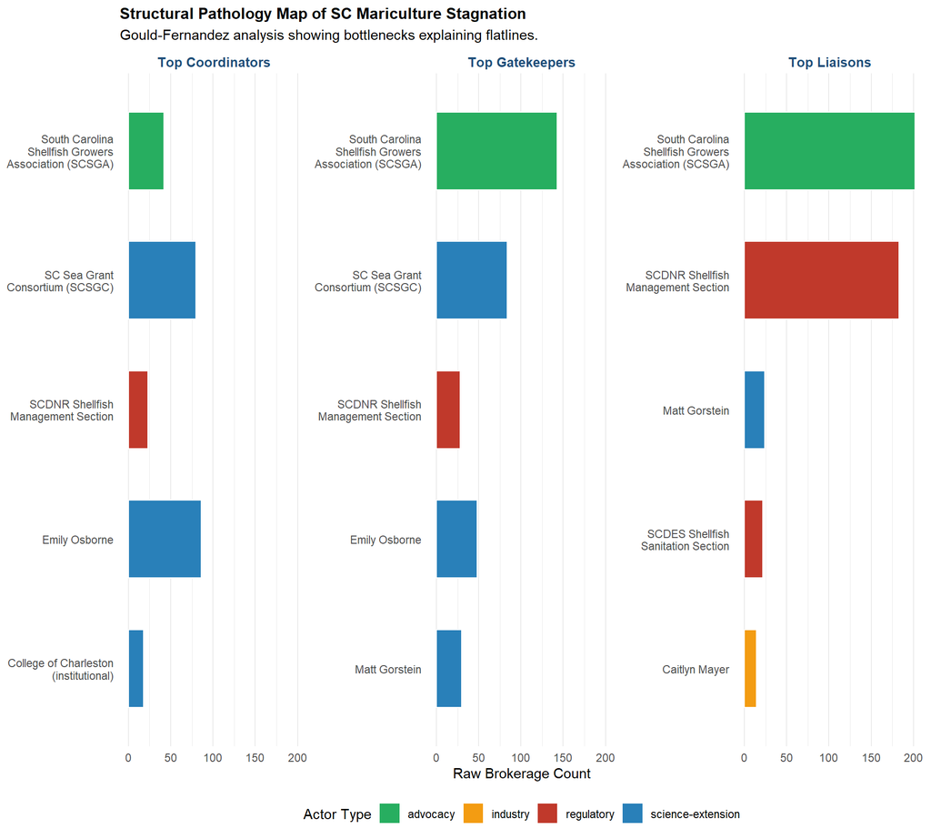

```r
top_gate <- results %>% select(name, actor_type, value = Gatekeeper) %>% mutate(Metric = "Top Gatekeepers") %>% arrange(desc(value)) %>% head(5)
top_liai <- results %>% select(name, actor_type, value = Liaison) %>% mutate(Metric = "Top Liaisons") %>% arrange(desc(value)) %>% head(5)
top_coor <- results %>% select(name, actor_type, value = Coordinator) %>% mutate(Metric = "Top Coordinators") %>% arrange(desc(value)) %>% head(5)

brok_plot_df <- bind_rows(top_gate, top_liai, top_coor)

ggplot(brok_plot_df, aes(x = reorder(str_wrap(name, 22), value), y = value, fill = actor_type)) +
  geom_col(color = "white", width = 0.6) +
  facet_wrap(~Metric, scales = "free_y", ncol = 3) +
  scale_fill_manual(values = actor_colors, name = "Actor Type") +
  coord_flip() +
  labs(x = NULL, y = "Raw Brokerage Count",
       title = "Structural Pathology Map of SC Mariculture Stagnation",
       subtitle = "Gould-Fernandez analysis showing bottlenecks explaining flatlines.") +
  theme_minimal() +
  theme(strip.text = element_text(face="bold", size=10, color="#1F4E79"),
        plot.title = element_text(face="bold", size=12),
        panel.grid.major.y = element_blank(),
        legend.position = "bottom")
```